# Cell2Cell | Data cleaning and shared split

We used the supplied Cell2Cell CSV, a cross-sectional record of customer usage, billing, service, equipment, and retention history. The file contains 51,047 customers and 58 fields, including 14,711 recorded churners (28.8%). The case dictionary describes approximately 71,000 customers. The supplied file defines the analysis sample. The binary churn outcome has no verified prediction horizon, so its sample rate cannot be read as monthly churn.

The business question is which customers to review first when the retention team has limited outreach capacity. Cleaning keeps the recorded values and their units traceable across model comparisons.

The churn label describes the recorded observation period. In the raw CSV, `Yes` means the customer left and `No` means they stayed during that period.

## Data preparation

```r
customers <- read.csv(
  "Provided_Data/cell2celltrain.csv",
  na.strings = c("", "NA"), stringsAsFactors = FALSE
)

stopifnot(!anyNA(customers$CustomerID),
          anyDuplicated(customers$CustomerID) == 0L,
          !anyNA(customers$Churn),
          setequal(unique(customers$Churn), c("No", "Yes")))

knitr::kable(
  data.frame(
    Customers = nrow(customers),
    Fields = ncol(customers),
    `Duplicate rows` = sum(duplicated(customers)),
    check.names = FALSE
  ),
  caption = "Source file at a glance",
  format.args = list(big.mark = ",")
)
```

Source file at a glance

| Customers | Fields | Duplicate rows |
| --- | --- | --- |
| 51,047 | 58 | 0 |

```r
churn_label <- factor(customers$Churn, levels = c("No", "Yes"),
                      labels = c("Did not churn", "Churned"))
knitr::kable(as.data.frame(table(churn_label)),
             col.names = c("Observed churn outcome", "Customers"),
             format.args = list(big.mark = ","))
```

| Observed churn outcome | Customers |
| --- | --- |
| Did not churn | 36,336 |
| Churned | 14,711 |

```r
missing <- sort(colSums(is.na(customers)), decreasing = TRUE)
```

### Imported fields and missing counts

```r
knitr::kable(data.frame(
  field = names(missing),
  imported_type = vapply(customers[names(missing)], class, character(1)),
  missing = unname(missing),
  row.names = NULL
), col.names = c("Field", "Imported type", "Missing cells"))
```

| Field | Imported type | Missing cells |
| --- | --- | --- |
| AgeHH1 | integer | 909 |
| AgeHH2 | integer | 909 |
| PercChangeMinutes | integer | 367 |
| PercChangeRevenues | numeric | 367 |
| MonthlyRevenue | numeric | 156 |
| MonthlyMinutes | integer | 156 |
| TotalRecurringCharge | integer | 156 |
| DirectorAssistedCalls | numeric | 156 |
| OverageMinutes | integer | 156 |
| RoamingCalls | numeric | 156 |
| ServiceArea | character | 24 |
| Handsets | integer | 1 |
| HandsetModels | integer | 1 |
| CurrentEquipmentDays | integer | 1 |
| CustomerID | integer | 0 |
| Churn | character | 0 |
| DroppedCalls | numeric | 0 |
| BlockedCalls | numeric | 0 |
| UnansweredCalls | numeric | 0 |
| CustomerCareCalls | numeric | 0 |
| ThreewayCalls | numeric | 0 |
| ReceivedCalls | numeric | 0 |
| OutboundCalls | numeric | 0 |
| InboundCalls | numeric | 0 |
| PeakCallsInOut | numeric | 0 |
| OffPeakCallsInOut | numeric | 0 |
| DroppedBlockedCalls | numeric | 0 |
| CallForwardingCalls | numeric | 0 |
| CallWaitingCalls | numeric | 0 |
| MonthsInService | integer | 0 |
| UniqueSubs | integer | 0 |
| ActiveSubs | integer | 0 |
| ChildrenInHH | character | 0 |
| HandsetRefurbished | character | 0 |
| HandsetWebCapable | character | 0 |
| TruckOwner | character | 0 |
| RVOwner | character | 0 |
| Homeownership | character | 0 |
| BuysViaMailOrder | character | 0 |
| RespondsToMailOffers | character | 0 |
| OptOutMailings | character | 0 |
| NonUSTravel | character | 0 |
| OwnsComputer | character | 0 |
| HasCreditCard | character | 0 |
| RetentionCalls | integer | 0 |
| RetentionOffersAccepted | integer | 0 |
| NewCellphoneUser | character | 0 |
| NotNewCellphoneUser | character | 0 |
| ReferralsMadeBySubscriber | integer | 0 |
| IncomeGroup | integer | 0 |
| OwnsMotorcycle | character | 0 |
| AdjustmentsToCreditRating | integer | 0 |
| HandsetPrice | character | 0 |
| MadeCallToRetentionTeam | character | 0 |
| CreditRating | character | 0 |
| PrizmCode | character | 0 |
| Occupation | character | 0 |
| MaritalStatus | character | 0 |

```r
source_flags <- c(
  unknown_handset_price = sum(customers$HandsetPrice == "Unknown", na.rm = TRUE),
  zero_age_hh1 = sum(customers$AgeHH1 == 0, na.rm = TRUE),
  zero_age_hh2 = sum(customers$AgeHH2 == 0, na.rm = TRUE),
  negative_equipment_days = sum(customers$CurrentEquipmentDays < 0, na.rm = TRUE),
  negative_monthly_revenue = sum(customers$MonthlyRevenue < 0, na.rm = TRUE)
)
knitr::kable(
  data.frame(
    Check = c("Unknown handset prices", "Zero primary household ages",
              "Zero secondary household ages", "Negative equipment days",
              "Negative monthly revenue"),
    Customers = unname(source_flags)
  ),
  caption = "Source values flagged for review",
  format.args = list(big.mark = ",")
)
```

Source values flagged for review

| Check | Customers |
| --- | --- |
| Unknown handset prices | 28,982 |
| Zero primary household ages | 13,917 |
| Zero secondary household ages | 26,087 |
| Negative equipment days | 76 |
| Negative monthly revenue | 3 |

### Cleaning rules

| Item | What happened in the shared dataset | Why |
| --- | --- | --- |
| Blank fields and literal `NA` tokens | Set to R’s `NA` when reading the source CSV through `na.strings = c("", "NA")`. | They represent unavailable values. |
| `HandsetPrice` | Set all 28,982 cells containing the literal text `Unknown` to R’s `NA`, then converted the column to numeric USD. The resulting missing prices are numeric `NA` values. | Recorded prices can now be summarized and modeled as amounts. |
| `CurrentEquipmentDays` | Replaced negative values with `NA`. | Elapsed time with a handset must be zero or positive. |
| Zero household ages | Flagged for review and kept as recorded. | The meaning of zero is unverified, and age is outside the current predictor sets. |
| Negative monthly revenue | Flagged for review and kept in USD. | Signed amounts may reflect billing adjustments. |
| Scaling and clipping | Kept original units. No z-score standardization, min–max normalization, or outlier clipping was applied. | The current unpenalized logistic models can fit predictors in different units. Original units make revenue, tenure, and usage easier to interpret. |
| Customer records | Checked that customer IDs were unique and that every row had a valid churn label. Kept all rows. | Records with missing predictors can still contribute valid data. |

```r
prepared <- customers
price <- prepared$HandsetPrice
price[which(price == "Unknown")] <- NA
prepared$HandsetPrice <- as.numeric(price)
stopifnot(all(is.na(price) == is.na(prepared$HandsetPrice)))

invalid_equipment <- which(prepared$CurrentEquipmentDays < 0)
prepared$CurrentEquipmentDays[invalid_equipment] <- NA
missing_after_cleaning <- sort(colSums(is.na(prepared)), decreasing = TRUE)
```

### Cleaned fields and missing counts

```r
knitr::kable(data.frame(
  field = names(missing_after_cleaning),
  cleaned_type = vapply(prepared[names(missing_after_cleaning)], class, character(1)),
  missing_after_cleaning = unname(missing_after_cleaning),
  row.names = NULL
), col.names = c("Field", "Cleaned type", "Missing cells"))
```

| Field | Cleaned type | Missing cells |
| --- | --- | --- |
| HandsetPrice | numeric | 28982 |
| AgeHH1 | integer | 909 |
| AgeHH2 | integer | 909 |
| PercChangeMinutes | integer | 367 |
| PercChangeRevenues | numeric | 367 |
| MonthlyRevenue | numeric | 156 |
| MonthlyMinutes | integer | 156 |
| TotalRecurringCharge | integer | 156 |
| DirectorAssistedCalls | numeric | 156 |
| OverageMinutes | integer | 156 |
| RoamingCalls | numeric | 156 |
| CurrentEquipmentDays | integer | 77 |
| ServiceArea | character | 24 |
| Handsets | integer | 1 |
| HandsetModels | integer | 1 |
| CustomerID | integer | 0 |
| Churn | character | 0 |
| DroppedCalls | numeric | 0 |
| BlockedCalls | numeric | 0 |
| UnansweredCalls | numeric | 0 |
| CustomerCareCalls | numeric | 0 |
| ThreewayCalls | numeric | 0 |
| ReceivedCalls | numeric | 0 |
| OutboundCalls | numeric | 0 |
| InboundCalls | numeric | 0 |
| PeakCallsInOut | numeric | 0 |
| OffPeakCallsInOut | numeric | 0 |
| DroppedBlockedCalls | numeric | 0 |
| CallForwardingCalls | numeric | 0 |
| CallWaitingCalls | numeric | 0 |
| MonthsInService | integer | 0 |
| UniqueSubs | integer | 0 |
| ActiveSubs | integer | 0 |
| ChildrenInHH | character | 0 |
| HandsetRefurbished | character | 0 |
| HandsetWebCapable | character | 0 |
| TruckOwner | character | 0 |
| RVOwner | character | 0 |
| Homeownership | character | 0 |
| BuysViaMailOrder | character | 0 |
| RespondsToMailOffers | character | 0 |
| OptOutMailings | character | 0 |
| NonUSTravel | character | 0 |
| OwnsComputer | character | 0 |
| HasCreditCard | character | 0 |
| RetentionCalls | integer | 0 |
| RetentionOffersAccepted | integer | 0 |
| NewCellphoneUser | character | 0 |
| NotNewCellphoneUser | character | 0 |
| ReferralsMadeBySubscriber | integer | 0 |
| IncomeGroup | integer | 0 |
| OwnsMotorcycle | character | 0 |
| AdjustmentsToCreditRating | integer | 0 |
| MadeCallToRetentionTeam | character | 0 |
| CreditRating | character | 0 |
| PrizmCode | character | 0 |
| Occupation | character | 0 |
| MaritalStatus | character | 0 |

### Before and after cleaning

The field-level table counts missing cells. The customer-level table counts each customer once if any field is missing.

```r
source_tokens <- read.csv("Provided_Data/cell2celltrain.csv",
                          colClasses = "character", na.strings = NULL)
knitr::kable(data.frame(
  source_encoding = c("Empty field", "Literal NA"),
  imported_as_na = c(sum(source_tokens == "", na.rm = TRUE),
                     sum(source_tokens == "NA", na.rm = TRUE))
))
```

| source_encoding | imported_as_na |
| --- | --- |
| Empty field | 24 |
| Literal NA | 3491 |

```r
knitr::kable(data.frame(
  field = c("HandsetPrice", "CurrentEquipmentDays"),
  newly_marked_missing = c(sum(customers$HandsetPrice == "Unknown", na.rm = TRUE),
                           length(invalid_equipment)),
  missing_before = unname(missing[c("HandsetPrice", "CurrentEquipmentDays")]),
  missing_after = unname(missing_after_cleaning[c("HandsetPrice", "CurrentEquipmentDays")])
))
```

| field | newly_marked_missing | missing_before | missing_after |
| --- | --- | --- | --- |
| HandsetPrice | 28982 | 0 | 28982 |
| CurrentEquipmentDays | 76 | 1 | 77 |

```r
knitr::kable(data.frame(
  measure = c("Customer rows", "Cells marked missing", "Rows with any missing field"),
  before = c(nrow(customers), sum(missing), sum(!complete.cases(customers))),
  after = c(nrow(prepared), sum(missing_after_cleaning), sum(!complete.cases(prepared)))
))
```

| measure | before | after |
| --- | --- | --- |
| Customer rows | 51047 | 51047 |
| Cells marked missing | 3515 | 32573 |
| Rows with any missing field | 1295 | 29632 |

### How cleaning changed the recorded missingness

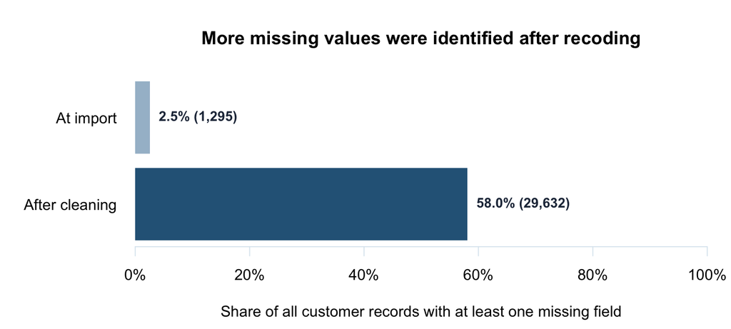

```r
incomplete_counts <- c(sum(!complete.cases(customers)), sum(!complete.cases(prepared)))
incomplete_pct <- 100 * incomplete_counts / nrow(customers)
old_par <- par(mar = c(4.5, 7.4, 4.1, 1.3))
positions <- barplot(
  rev(incomplete_pct), horiz = TRUE, names.arg = c("After cleaning", "At import"),
  las = 1, xlim = c(0, 100), xaxt = "n", border = NA,
  col = c("#2B6387", "#A5BDD0"),
  main = "More missing values were identified after recoding",
  xlab = "Share of all customer records with at least one missing field"
)
ticks <- seq(0, 100, 20)
axis(1, at = ticks, labels = paste0(ticks, "%"), col = "#DCE8F0")
text(rev(incomplete_pct), positions,
     labels = sprintf("%.1f%% (%s)", rev(incomplete_pct),
                      format(rev(incomplete_counts), big.mark = ",", trim = TRUE)),
     pos = 4, font = 2, col = "#243247", cex = 0.9)
```

```r
par(old_par)
```

### What this means

Before cleaning, `HandsetPrice` had **0 cells counted as missing** because the source encoded 28,982 unavailable prices as the literal text `Unknown`. R counted that text as a recorded value. After replacing each `Unknown` with R’s `NA`, the missing-price count rose to **28,982**. Those prices were already unavailable in the source data. Cleaning made that explicit.

For `CurrentEquipmentDays`, the missing count rose from **1 to 77** because 76 negative values were replaced with `NA`. Together, these two changes account for the increase from **3,515 to 32,573** cells counted as missing.

### Where missing values are filled

R stores missing values as `NA`. The export uses `write.csv(..., na = "")`, so those cells appear as empty fields in the shared CSV. EDA reports missingness where applicable. In `03_Variable_Selection.Rmd`, each cross-validation fit fills missing numeric predictors with the median of observed values in that fold’s fitting rows. For example, a missing handset price in a validation row gets the median recorded price from the fitting rows. Missing categorical predictors use the most frequent category in the fitting rows. These temporary replacements apply to both fitting and validation data and stay inside the modeling step. This prevents validation data from influencing imputation.

### Field consistency checks

```r
knitr::kable(data.frame(
  check = c("Active lines exceed unique lines", "Zero usage with positive dropped calls",
            "Combined network count differs from sum by more than 0.1"),
  flagged = with(prepared, c(
    sum(ActiveSubs > UniqueSubs, na.rm = TRUE),
    sum(MonthlyMinutes == 0 & DroppedCalls > 0, na.rm = TRUE),
    sum(abs(DroppedBlockedCalls - DroppedCalls - BlockedCalls) > 0.1, na.rm = TRUE)
  )),
  comparable = with(prepared, c(
    sum(complete.cases(ActiveSubs, UniqueSubs)),
    sum(complete.cases(MonthlyMinutes, DroppedCalls)),
    sum(complete.cases(DroppedBlockedCalls, DroppedCalls, BlockedCalls))
  ))
))
```

| check | flagged | comparable |
| --- | --- | --- |
| Active lines exceed unique lines | 0 | 51047 |
| Zero usage with positive dropped calls | 12 | 50891 |
| Combined network count differs from sum by more than 0.1 | 5695 | 51047 |

### Seasonality and calendar dates

The case dictionary describes one cross-sectional record per customer. The CSV has no observation date, billing period, or churn event date. The quarter-over-quarter change fields show the direction and size of a change but do not identify calendar quarters. `MonthsInService` measures elapsed tenure. A change by tenure cannot be assigned to November or Black Friday. Testing seasonality would require dated customer billing or usage records spanning multiple periods. Daily or weekly dates would be needed to isolate Black Friday from the rest of November.

## Shared training, test, and cross-validation assignments

We use a 75/25 split stratified by churn and three stratified CV folds within training, with seed 445 for each assignment. This preserves the assignments used in the preliminary analysis. The test partition has a blank CV fold. For fold 1, the model fits on folds 2 and 3 and scores fold 1. Each training fold serves as validation once. The test partition is reserved for final evaluation after the team locks the model and predictors.

```r
set.seed(445)
by_churn <- split(seq_len(nrow(prepared)), prepared$Churn)
train_rows <- unlist(lapply(by_churn, function(rows) {
  sample(rows, floor(0.75 * length(rows)))
}), use.names = FALSE)
test_rows <- setdiff(seq_len(nrow(prepared)), train_rows)
manifest_rows <- c(train_rows, test_rows)
manifest <- data.frame(
  CustomerID = prepared$CustomerID[manifest_rows],
  split = rep(c("train", "test"), c(length(train_rows), length(test_rows))),
  cv_fold = NA_integer_
)

set.seed(445)
train_by_churn <- split(seq_along(train_rows), prepared$Churn[train_rows])
for (rows in train_by_churn) {
  manifest$cv_fold[rows] <- sample(rep(1:3, length.out = length(rows)))
}

stopifnot(nrow(prepared) == nrow(customers),
          identical(prepared$CustomerID, customers$CustomerID),
          identical(prepared$MonthlyRevenue, customers$MonthlyRevenue),
          !anyDuplicated(manifest$CustomerID),
          setequal(prepared$CustomerID, manifest$CustomerID),
          all(manifest$cv_fold[manifest$split == "train"] %in% 1:3),
          all(is.na(manifest$cv_fold[manifest$split == "test"])))
split_labels <- factor(manifest$split, levels = c("train", "test"),
                       labels = c("Training", "Reserved test"))
knitr::kable(as.data.frame.matrix(table(split_labels, churn_label[manifest_rows])),
             caption = "Customer counts by partition and observed churn outcome",
             format.args = list(big.mark = ","))
```

Customer counts by partition and observed churn outcome

|  | Did not churn | Churned |
| --- | --- | --- |
| Training | 27,252 | 11,033 |
| Reserved test | 9,084 | 3,678 |

```r
knitr::kable(as.data.frame.matrix(table(manifest$cv_fold, churn_label[manifest_rows])),
             caption = "Customer counts within each training fold",
             format.args = list(big.mark = ","))
```

Customer counts within each training fold

| Did not churn | Churned |
| --- | --- |
| 9,084 | 3,678 |
| 9,084 | 3,678 |
| 9,084 | 3,677 |

```r
dir.create("Generated_Data", showWarnings = FALSE)
write.csv(prepared, "Generated_Data/cleaned_data.csv", row.names = FALSE, na = "")
write.csv(manifest, "Generated_Data/split_manifest.csv", row.names = FALSE, na = "")
```

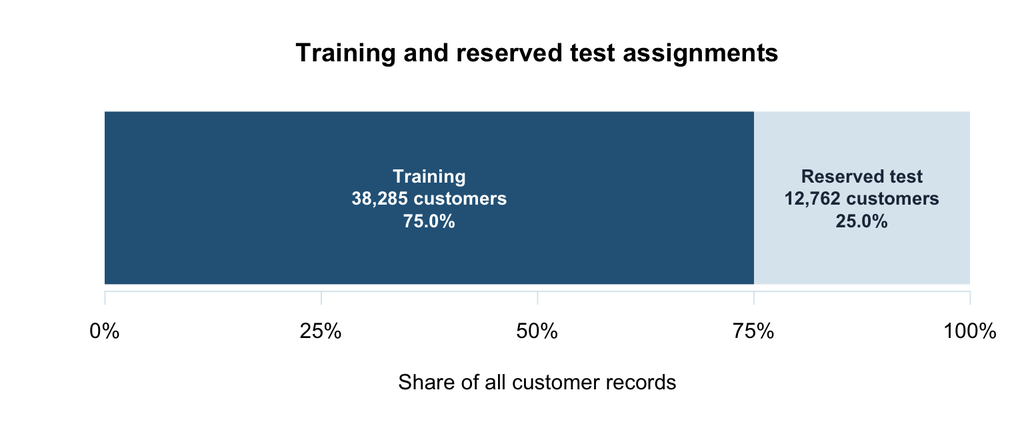

```r
partition_counts <- c(length(train_rows), length(test_rows))
partition_shares <- 100 * partition_counts / sum(partition_counts)
positions <- barplot(
  matrix(partition_shares, ncol = 1), horiz = TRUE,
  xlim = c(0, 100), xaxt = "n", yaxt = "n", border = NA,
  col = c("#2B6387", "#DCE8F0"),
  main = "Training and reserved test assignments",
  xlab = "Share of all customer records"
)
ticks <- seq(0, 100, 25)
axis(1, at = ticks, labels = paste0(ticks, "%"), col = "#DCE8F0")
text(cumsum(partition_shares) - partition_shares / 2, rep(positions, 2),
     labels = sprintf("%s\n%s customers\n%.1f%%", c("Training", "Reserved test"),
                      format(partition_counts, big.mark = ",", trim = TRUE),
                      partition_shares),
     col = c("white", "#243247"), font = 2, cex = 0.87)
```

The three validation folds are drawn from the training segment. The reserved test segment stays outside feature and model selection.

The cleaned master retains all source columns for auditing and exploration. `CustomerID` joins the master to the split manifest. The modeling notebooks use `R/preprocessing.R` to create temporary fold-specific copies. The master retains observed monthly revenue for the finance handoff.